## Variable Selection

### Digits Data

This is actually NOT a good example for regression since the response is binary, not numeric. It is used to illustrate the point that **less-could-be-better** for prediction (less = less predictors)

```r
load(file="dig14.Rdata")
dim(tr14)
```

```
## [1] 464 257
```

```r
dim(test14)
```

```
## [1] 1657  257
```

```r
names(tr14)
```

```
##   [1] "Y"    "V1"   "V2"   "V3"   "V4"   "V5"   "V6"   "V7"   "V8"   "V9"
##  [11] "V10"  "V11"  "V12"  "V13"  "V14"  "V15"  "V16"  "V17"  "V18"  "V19"
##  [21] "V20"  "V21"  "V22"  "V23"  "V24"  "V25"  "V26"  "V27"  "V28"  "V29"
##  [31] "V30"  "V31"  "V32"  "V33"  "V34"  "V35"  "V36"  "V37"  "V38"  "V39"
##  [41] "V40"  "V41"  "V42"  "V43"  "V44"  "V45"  "V46"  "V47"  "V48"  "V49"
##  [51] "V50"  "V51"  "V52"  "V53"  "V54"  "V55"  "V56"  "V57"  "V58"  "V59"
##  [61] "V60"  "V61"  "V62"  "V63"  "V64"  "V65"  "V66"  "V67"  "V68"  "V69"
##  [71] "V70"  "V71"  "V72"  "V73"  "V74"  "V75"  "V76"  "V77"  "V78"  "V79"
##  [81] "V80"  "V81"  "V82"  "V83"  "V84"  "V85"  "V86"  "V87"  "V88"  "V89"
##  [91] "V90"  "V91"  "V92"  "V93"  "V94"  "V95"  "V96"  "V97"  "V98"  "V99"
## [101] "V100" "V101" "V102" "V103" "V104" "V105" "V106" "V107" "V108" "V109"
## [111] "V110" "V111" "V112" "V113" "V114" "V115" "V116" "V117" "V118" "V119"
## [121] "V120" "V121" "V122" "V123" "V124" "V125" "V126" "V127" "V128" "V129"
## [131] "V130" "V131" "V132" "V133" "V134" "V135" "V136" "V137" "V138" "V139"
## [141] "V140" "V141" "V142" "V143" "V144" "V145" "V146" "V147" "V148" "V149"
## [151] "V150" "V151" "V152" "V153" "V154" "V155" "V156" "V157" "V158" "V159"
## [161] "V160" "V161" "V162" "V163" "V164" "V165" "V166" "V167" "V168" "V169"
## [171] "V170" "V171" "V172" "V173" "V174" "V175" "V176" "V177" "V178" "V179"
## [181] "V180" "V181" "V182" "V183" "V184" "V185" "V186" "V187" "V188" "V189"
## [191] "V190" "V191" "V192" "V193" "V194" "V195" "V196" "V197" "V198" "V199"
## [201] "V200" "V201" "V202" "V203" "V204" "V205" "V206" "V207" "V208" "V209"
## [211] "V210" "V211" "V212" "V213" "V214" "V215" "V216" "V217" "V218" "V219"
## [221] "V220" "V221" "V222" "V223" "V224" "V225" "V226" "V227" "V228" "V229"
## [231] "V230" "V231" "V232" "V233" "V234" "V235" "V236" "V237" "V238" "V239"
## [241] "V240" "V241" "V242" "V243" "V244" "V245" "V246" "V247" "V248" "V249"
## [251] "V250" "V251" "V252" "V253" "V254" "V255" "V256"
```

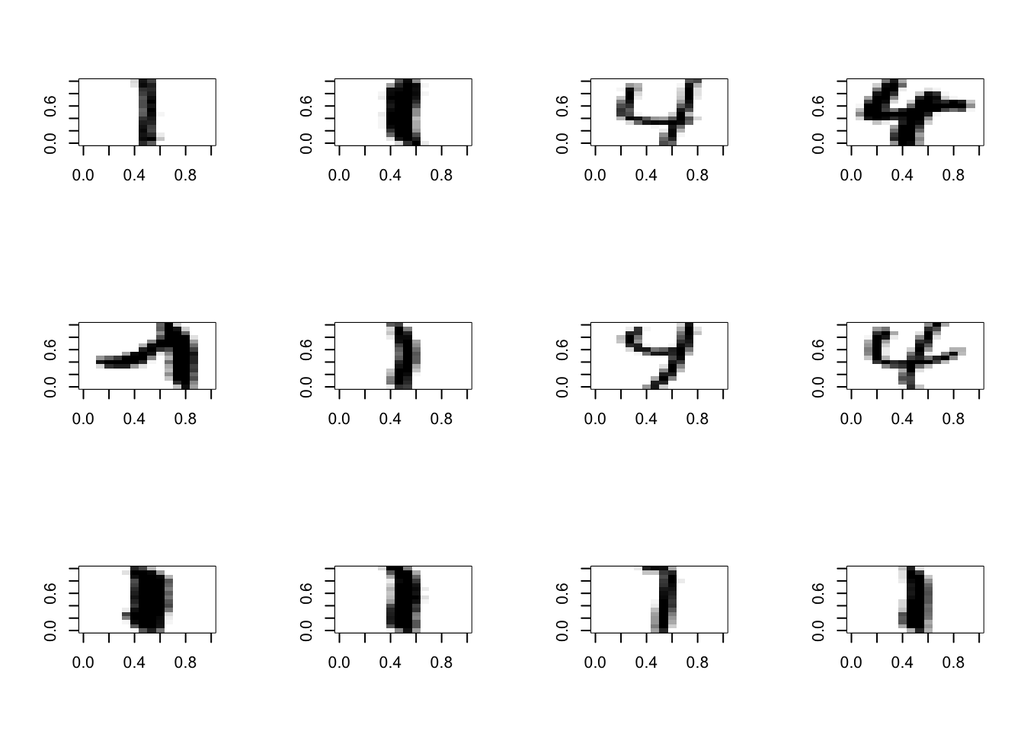

```r
ntrain=dim(tr14)[1]
ntest = dim(test14)[1]
par(mfrow=c(3,4));
for(i in 1:12){
 tmp=matrix(as.numeric(tr14[sample(ntrain,1),2:257]),16,16);
 tmp=tmp[,16:1]
 image(tmp,col=gray((32:0)/32)); }
```

```r
# image size: 16x16=256  pixels
```

Use the 256 features (each corresponds to a pixel) to train a regression model to predict Y, which is either 1 (if Y=1) or 0 (if Y=4)

```r
tr14$Y = ifelse(tr14$Y==1, 1, 0);
test14$Y = ifelse(test14$Y==1, 1, 0);
g0=lm(Y~., data=tr14);
summary(g0)
```

```
##
## Call:
## lm(formula = Y ~ ., data = tr14)
##
## Residuals:
##      Min       1Q   Median       3Q      Max
## -0.70832 -0.02442  0.00000  0.02902  0.24802
##
## Coefficients: (8 not defined because of singularities)
##               Estimate Std. Error t value Pr(>|t|)
## (Intercept) -1.941e+02  2.862e+02  -0.678 0.498386
## V1           2.471e+03  1.240e+03   1.993 0.047568 *
## V2          -1.934e+02  9.913e+01  -1.951 0.052357 .
## V3           2.155e+00  1.771e+00   1.217 0.225069
## V4           2.769e-01  5.004e-01   0.553 0.580597
## V5          -1.152e-01  1.631e-01  -0.706 0.480924
## V6           7.183e-02  9.576e-02   0.750 0.454006
## V7           2.429e-02  2.747e-02   0.884 0.377601
## V8          -7.097e-03  2.295e-02  -0.309 0.757442
## V9           5.606e-03  2.164e-02   0.259 0.795851
## V10         -4.377e-02  3.553e-02  -1.232 0.219335
## V11         -1.032e-01  5.920e-02  -1.744 0.082615 .
## V12          7.703e-02  7.494e-02   1.028 0.305178
## V13         -2.082e-01  1.072e-01  -1.943 0.053322 .
## V14         -2.232e-01  1.272e-01  -1.754 0.080789 .
## V15          2.951e-01  3.596e-01   0.821 0.412731
## V16          6.397e-01  1.362e+00   0.470 0.639129
## V17         -2.229e+03  1.108e+03  -2.011 0.045548 *
## V18          2.888e+01  1.466e+01   1.969 0.050183 .
## V19         -1.616e+00  1.454e+00  -1.111 0.267708
## V20         -3.186e-01  1.635e-01  -1.948 0.052671 .
## V21          2.161e-01  9.234e-02   2.340 0.020191 *
## V22         -8.817e-02  6.485e-02  -1.360 0.175406
## V23          5.282e-02  3.627e-02   1.456 0.146738
## V24          2.892e-02  4.049e-02   0.714 0.475843
## V25         -2.910e-02  3.358e-02  -0.867 0.387133
## V26          2.922e-02  3.282e-02   0.890 0.374251
## V27          5.503e-02  7.708e-02   0.714 0.476068
## V28         -1.796e-01  8.462e-02  -2.122 0.034987 *
## V29          2.096e-01  1.534e-01   1.367 0.173138
```

[output cut: 218 more lines]

```
## V248        -1.827e-02  2.720e-02  -0.672 0.502574
## V249        -4.287e-02  2.359e-02  -1.818 0.070514 .
## V250         2.795e-02  2.622e-02   1.066 0.287729
## V251         9.692e-02  6.094e-02   1.590 0.113226
## V252        -1.629e-02  8.905e-02  -0.183 0.855024
## V253         1.707e+00  6.381e-01   2.675 0.008044 **
## V254        -8.636e+00  3.440e+00  -2.511 0.012791 *
## V255                NA         NA      NA       NA
## V256                NA         NA      NA       NA
## ---
## Signif. codes:  0 '***' 0.001 '**' 0.01 '*' 0.05 '.' 0.1 ' ' 1
##
## Residual standard error: 0.09679 on 215 degrees of freedom
## Multiple R-squared:  0.9823, Adjusted R-squared:  0.9619
## F-statistic: 48.11 on 248 and 215 DF,  p-value: < 2.2e-16
```

Compute the training error and test error.

```r
tr14.pred = g0$fitted>0.5
table(tr14.pred, tr14$Y)
```

```
##
## tr14.pred   0   1
##     FALSE 199   0
##     TRUE    1 264
```

```r
training.err = mean(tr14.pred != tr14$Y)
training.err
```

```
## [1] 0.002155172
```

```r
te14.pred = predict(g0, newdata=test14)>0.5;
table(te14.pred , test14$Y)
```

```
##
## te14.pred    0    1
##     FALSE  476    3
##     TRUE   176 1002
```

```r
test.err = mean(te14.pred != test14$Y)
test.err
```

```
## [1] 0.1080266
```

```r
g0.coef=summary(g0)$coef
g1.var = row.names(g0.coef)[g0.coef[,4]<0.05]
g1.var
```

```
##  [1] "V1"   "V17"  "V21"  "V28"  "V33"  "V45"  "V46"  "V50"  "V51"  "V71"
## [11] "V87"  "V88"  "V89"  "V97"  "V100" "V105" "V114" "V123" "V127" "V141"
## [21] "V152" "V158" "V159" "V160" "V161" "V163" "V168" "V173" "V174" "V180"
## [31] "V186" "V190" "V191" "V197" "V203" "V222" "V243" "V245" "V253" "V254"
```

```r
m = length(g1.var)
g1.model=paste("Y ~", g1.var[1])
g1.model
```

```
## [1] "Y ~ V1"
```

```r
for(j in 2:m) g1.model=paste(g1.model, " + ", g1.var[j], sep="");
g1.model
```

```
## [1] "Y ~ V1 + V17 + V21 + V28 + V33 + V45 + V46 + V50 + V51 + V71 + V87 + V88 + V89 + V97 + V100 + V105 + V114 + V123 + V127 + V141 + V152 + V158 + V159 + V160 + V161 + V163 + V168 + V173 + V174 + V180 + V186 + V190 + V191 + V197 + V203 + V222 + V243 + V245 + V253 + V254"
```

```r
g1 = lm(g1.model, data=tr14)
summary(g1)
```

```
##
## Call:
## lm(formula = g1.model, data = tr14)
##
## Residuals:
##      Min       1Q   Median       3Q      Max
## -0.94921 -0.05432  0.01591  0.09475  0.66311
##
## Coefficients:
##              Estimate Std. Error t value Pr(>|t|)
## (Intercept)  1.547510   2.119045   0.730  0.46562
## V1          -7.179337   8.094699  -0.887  0.37563
## V17          8.439283   9.919466   0.851  0.39537
## V21         -0.089348   0.029827  -2.996  0.00290 **
## V28         -0.018962   0.024691  -0.768  0.44292
## V33          0.602115   0.919377   0.655  0.51288
## V45          0.017541   0.029218   0.600  0.54859
## V46          0.088061   0.041682   2.113  0.03521 *
## V50         -0.033818   0.084968  -0.398  0.69083
## V51         -0.042665   0.042344  -1.008  0.31423
## V71          0.055050   0.030465   1.807  0.07147 .
## V87         -0.154790   0.030390  -5.093 5.31e-07 ***
## V88          0.213171   0.024374   8.746  < 2e-16 ***
## V89          0.070630   0.036625   1.928  0.05447 .
## V97         -0.045498   0.061490  -0.740  0.45976
## V100        -0.136781   0.022114  -6.185 1.46e-09 ***
## V105        -0.004537   0.032680  -0.139  0.88965
## V114        -0.033375   0.038467  -0.868  0.38610
## V123        -0.136923   0.022895  -5.980 4.74e-09 ***
## V127        -0.046560   0.053718  -0.867  0.38657
## V141        -0.018986   0.027985  -0.678  0.49785
## V152        -0.075270   0.025924  -2.904  0.00388 **
## V158         0.006603   0.054221   0.122  0.90313
## V159        -0.012274   0.079631  -0.154  0.87758
## V160         0.082083   0.121024   0.678  0.49799
## V161        -0.125155   0.101727  -1.230  0.21926
## V163         0.080202   0.045433   1.765  0.07824 .
## V168         0.132952   0.025758   5.162 3.78e-07 ***
## V173        -0.042634   0.046374  -0.919  0.35843
## V174        -0.058764   0.063548  -0.925  0.35564
## V180        -0.143194   0.053880  -2.658  0.00817 **
## V186         0.047889   0.017204   2.784  0.00562 **
## V190        -0.073812   0.096432  -0.765  0.44444
## V191         0.063848   0.134599   0.474  0.63549
## V197        -0.068569   0.056400  -1.216  0.22476
## V203         0.013134   0.024263   0.541  0.58856
## V222        -0.014410   0.072731  -0.198  0.84304
## V243        -1.137426   0.674106  -1.687  0.09228 .
## V245         0.072664   0.091163   0.797  0.42585
## V253         0.045880   0.098799   0.464  0.64262
## V254         0.843130   0.504645   1.671  0.09551 .
## ---
## Signif. codes:  0 '***' 0.001 '**' 0.01 '*' 0.05 '.' 0.1 ' ' 1
##
## Residual standard error: 0.2055 on 423 degrees of freedom
## Multiple R-squared:  0.843,  Adjusted R-squared:  0.8282
## F-statistic: 56.78 on 40 and 423 DF,  p-value: < 2.2e-16
```

Compute the training error and test error.

```r
tr14.pred = g1$fitted>0.5
table(tr14.pred, tr14$Y)
```

```
##
## tr14.pred   0   1
##     FALSE 190   4
##     TRUE   10 260
```

```r
training.err = mean(tr14.pred != tr14$Y)
training.err
```

```
## [1] 0.03017241
```

```r
te14.pred = predict(g1, newdata=test14)>0.5;
table(te14.pred , test14$Y)
```

```
##
## te14.pred    0    1
##     FALSE  579    2
##     TRUE    73 1003
```

```r
test.err=mean(te14.pred != test14$Y)
test.err
```

```
## [1] 0.04526252
```

```r
g1.coef=summary(g1)$coef
g2.var = row.names(g1.coef)[g1.coef[,4]<0.05]
g2.var
```

```
##  [1] "V21"  "V46"  "V87"  "V88"  "V100" "V123" "V152" "V168" "V180" "V186"
```

```r
m = length(g2.var)
g2.model=paste("Y ~", g2.var[1])
for(j in 2:m) g2.model=paste(g2.model, " + ", g2.var[j], sep="");
g2.model
```

```
## [1] "Y ~ V21 + V46 + V87 + V88 + V100 + V123 + V152 + V168 + V180 + V186"
```

```r
g2 = lm(g2.model, data=tr14)
summary(g2)
```

```
##
## Call:
## lm(formula = g2.model, data = tr14)
##
## Residuals:
##      Min       1Q   Median       3Q      Max
## -0.90122 -0.06603  0.01198  0.11272  0.71738
##
## Coefficients:
##             Estimate Std. Error t value Pr(>|t|)
## (Intercept)  0.08005    0.03929   2.038 0.042174 *
## V21         -0.08565    0.02330  -3.676 0.000266 ***
## V46          0.02471    0.02441   1.012 0.311931
## V87         -0.13147    0.01688  -7.787 4.70e-14 ***
## V88          0.25273    0.02071  12.202  < 2e-16 ***
## V100        -0.16534    0.01815  -9.108  < 2e-16 ***
## V123        -0.14689    0.01973  -7.446 4.91e-13 ***
## V152        -0.06082    0.02236  -2.720 0.006772 **
## V168         0.12940    0.02183   5.927 6.12e-09 ***
## V180        -0.19545    0.03121  -6.263 8.79e-10 ***
## V186         0.04772    0.01606   2.971 0.003131 **
## ---
## Signif. codes:  0 '***' 0.001 '**' 0.01 '*' 0.05 '.' 0.1 ' ' 1
##
## Residual standard error: 0.2101 on 453 degrees of freedom
## Multiple R-squared:  0.8242, Adjusted R-squared:  0.8203
## F-statistic: 212.4 on 10 and 453 DF,  p-value: < 2.2e-16
```

Compute the training error and test error.

```r
tr14.pred = g2$fitted>0.5
table(tr14.pred, tr14$Y)
```

```
##
## tr14.pred   0   1
##     FALSE 188   8
##     TRUE   12 256
```

```r
training.err = mean(tr14.pred != tr14$Y)
training.err
```

```
## [1] 0.04310345
```

```r
te14.pred = predict(g2, newdata=test14)>0.5;
table(te14.pred , test14$Y)
```

```
##
## te14.pred    0    1
##     FALSE  591    4
##     TRUE    61 1001
```

```r
test.err=mean(te14.pred != test14$Y)
test.err
```

```
## [1] 0.03922752
```

Take a look of where the selected variables (i.e., pixels) are located.

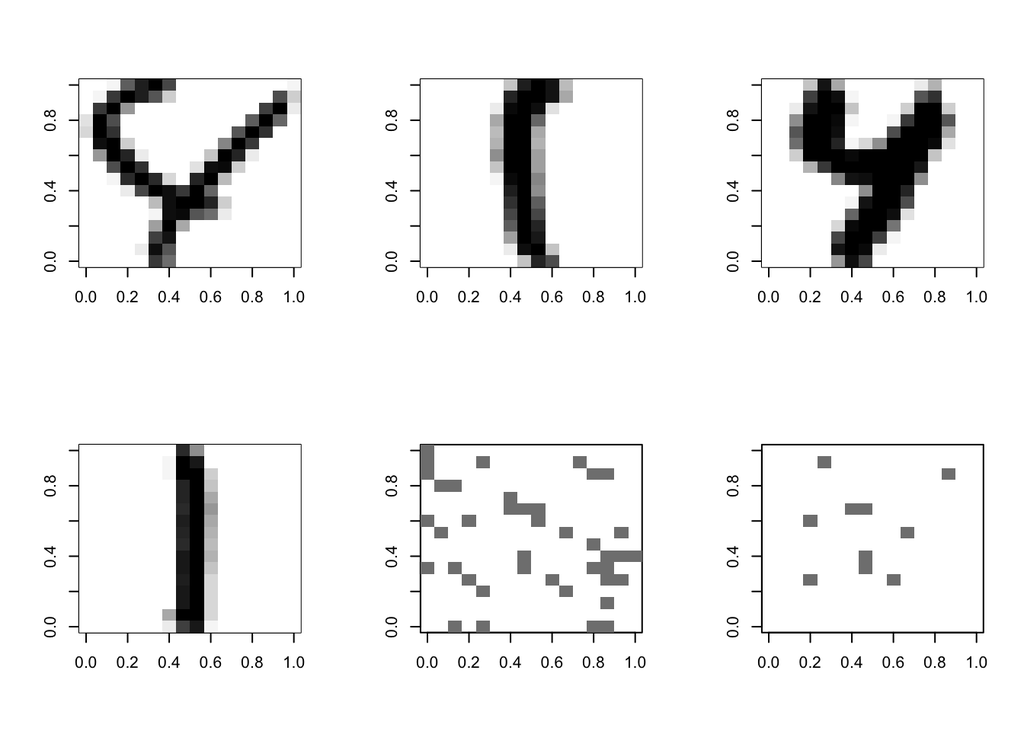

```r
par(mfrow=c(2,3))

for(i in 1:4){
 tmp=matrix(as.numeric(tr14[i,2:257]),16,16);
 tmp=tmp[,16:1];
 image(tmp,col=gray((32:0)/32));
 }

var.id=rep(0, 256);
var.id[names(tr14)[-1] %in% g1.var]=1;
var.id[var.id==0]=NA;
tmp=matrix(var.id,16,16);
tmp=tmp[,16:1]
image(tmp,col=gray((32:0)/32));
var.id=rep(0, 256);
var.id[names(tr14)[-1] %in% g2.var]=1;
var.id[var.id==0]=NA;
tmp=matrix(var.id,16,16);
tmp=tmp[,16:1]
image(tmp,col=gray((32:0)/32))
```

## State.x77 Data: matrix with 50 rows and 8 columns

- Population: population estimate as of July 1, 1975
- Income: per capita income (1974)
- Illiteracy: illiteracy (1970, percent of population)
- Life.Exp: life expectancy in years (1969–71)
- Murder: murder and non-negligent manslaughter rate per 100,000 population (1976)
- HS.Grad: percent high-school graduates (1970)
- Frost: mean number of days with minimum temperature below freezing (1931–1960) in capital or large city
- Area: land area in square miles

### Fit a linear regression model to predict Life Expectancy with all other 7 predictors.

```r
library(faraway)
# ?state.x77
statedata=data.frame(state.x77,row.names=state.abb,check.names=T)
g = lm(Life.Exp ~., data=statedata)
summary(g)
```

```
##
## Call:
## lm(formula = Life.Exp ~ ., data = statedata)
##
## Residuals:
##      Min       1Q   Median       3Q      Max
## -1.48895 -0.51232 -0.02747  0.57002  1.49447
##
## Coefficients:
##               Estimate Std. Error t value Pr(>|t|)
## (Intercept)  7.094e+01  1.748e+00  40.586  < 2e-16 ***
## Population   5.180e-05  2.919e-05   1.775   0.0832 .
## Income      -2.180e-05  2.444e-04  -0.089   0.9293
## Illiteracy   3.382e-02  3.663e-01   0.092   0.9269
## Murder      -3.011e-01  4.662e-02  -6.459 8.68e-08 ***
## HS.Grad      4.893e-02  2.332e-02   2.098   0.0420 *
## Frost       -5.735e-03  3.143e-03  -1.825   0.0752 .
## Area        -7.383e-08  1.668e-06  -0.044   0.9649
## ---
## Signif. codes:  0 '***' 0.001 '**' 0.01 '*' 0.05 '.' 0.1 ' ' 1
##
## Residual standard error: 0.7448 on 42 degrees of freedom
## Multiple R-squared:  0.7362, Adjusted R-squared:  0.6922
## F-statistic: 16.74 on 7 and 42 DF,  p-value: 2.534e-10
```

Check outliers

```r
n=dim(statedata)[1]
sort(abs(rstudent(g)), decreasing=TRUE)[1:5]
```

```
##       HI       ME       SC       AK       AR
## 2.735242 2.232206 1.615402 1.606163 1.562068
```

```r
qt(0.05/(n*2), 41)
```

```
## [1] -3.544184
```

Check high-influential points

```r
cook = cooks.distance(g)
max(cook)
```

```
## [1] 1.320804
```

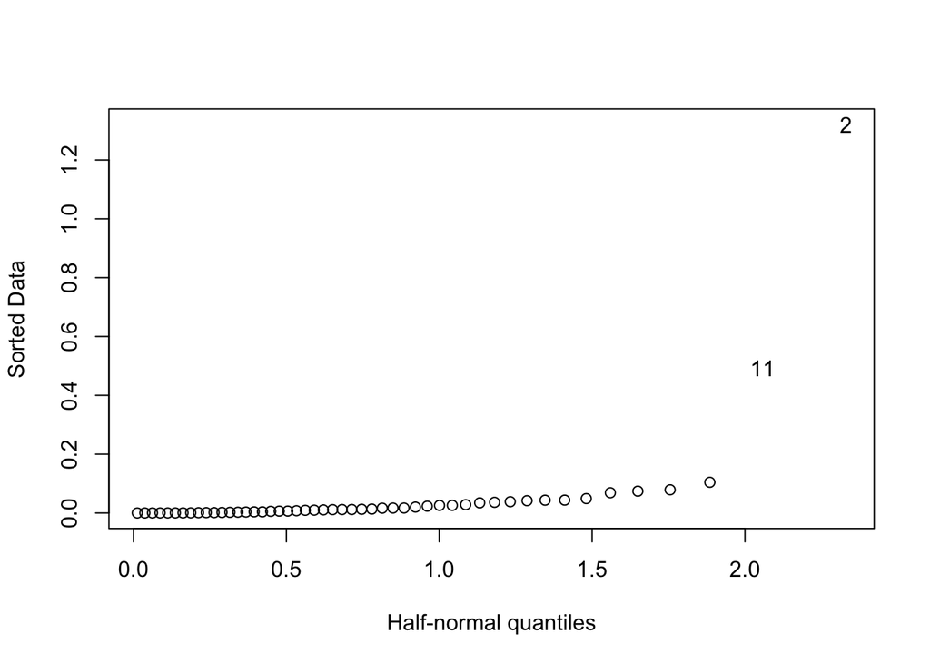

```r
#sort(cook)
halfnorm(cook)
```

Let’s first keep observation AK in our model, and then will repeat the analysis without AK.

Variable selection with `leaps` package.

```r
library(leaps)
b=regsubsets(Life.Exp~., data = statedata)
rs = summary(b)
rs$which
```

```
##   (Intercept) Population Income Illiteracy Murder HS.Grad Frost  Area
## 1        TRUE      FALSE  FALSE      FALSE   TRUE   FALSE FALSE FALSE
## 2        TRUE      FALSE  FALSE      FALSE   TRUE    TRUE FALSE FALSE
## 3        TRUE      FALSE  FALSE      FALSE   TRUE    TRUE  TRUE FALSE
## 4        TRUE       TRUE  FALSE      FALSE   TRUE    TRUE  TRUE FALSE
## 5        TRUE       TRUE   TRUE      FALSE   TRUE    TRUE  TRUE FALSE
## 6        TRUE       TRUE   TRUE       TRUE   TRUE    TRUE  TRUE FALSE
## 7        TRUE       TRUE   TRUE       TRUE   TRUE    TRUE  TRUE  TRUE
```

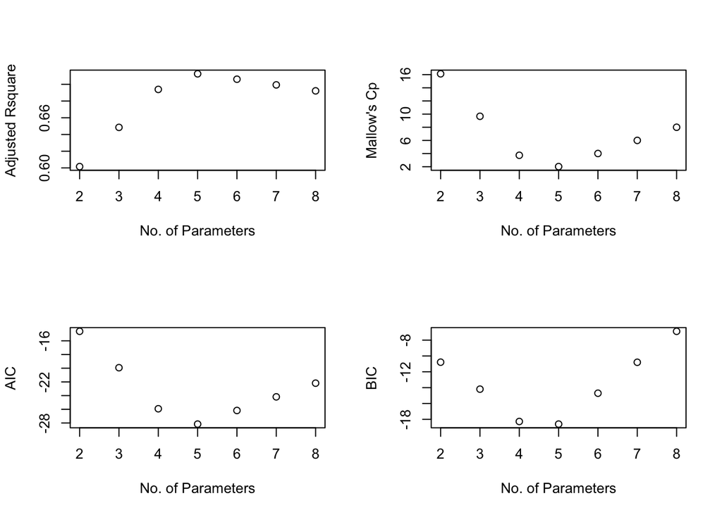

```r
n=dim(statedata)[1]; msize = 2:8;
par(mfrow=c(2,2))
plot(msize, rs$adjr2, xlab="No. of Parameters", ylab = "Adjusted Rsquare");
plot(msize, rs$cp, xlab="No. of Parameters", ylab = "Mallow's Cp");

Aic = n*log(rs$rss/n) + 2*msize;
Bic = n*log(rs$rss/n) + msize*log(n);
plot(msize, Aic, xlab="No. of Parameters", ylab = "AIC");
plot(msize, Bic, xlab="No. of Parameters", ylab = "BIC");
```

For this particular data set, AIC and BIC end up selecting the same model. Sometimes, the models selected by different criteria may be different.

```r
rs$which[which.min(Aic),]
```

```
## (Intercept)  Population      Income  Illiteracy      Murder     HS.Grad
##        TRUE        TRUE       FALSE       FALSE        TRUE        TRUE
##       Frost        Area
##        TRUE       FALSE
```

```r
select.var = colnames(rs$which)[rs$which[which.min(Aic),]]
select.var = select.var[-1]
myfit = lm(Life.Exp ~ . , data=statedata[, c(select.var, "Life.Exp")])
summary(myfit)
```

```
##
## Call:
## lm(formula = Life.Exp ~ ., data = statedata[, c(select.var, "Life.Exp")])
##
## Residuals:
##      Min       1Q   Median       3Q      Max
## -1.47095 -0.53464 -0.03701  0.57621  1.50683
##
## Coefficients:
##               Estimate Std. Error t value Pr(>|t|)
## (Intercept)  7.103e+01  9.529e-01  74.542  < 2e-16 ***
## Population   5.014e-05  2.512e-05   1.996  0.05201 .
## Murder      -3.001e-01  3.661e-02  -8.199 1.77e-10 ***
## HS.Grad      4.658e-02  1.483e-02   3.142  0.00297 **
## Frost       -5.943e-03  2.421e-03  -2.455  0.01802 *
## ---
## Signif. codes:  0 '***' 0.001 '**' 0.01 '*' 0.05 '.' 0.1 ' ' 1
##
## Residual standard error: 0.7197 on 45 degrees of freedom
## Multiple R-squared:  0.736,  Adjusted R-squared:  0.7126
## F-statistic: 31.37 on 4 and 45 DF,  p-value: 1.696e-12
```

`leaps` does not return AIC, but BIC. Its BIC differs from what I compute above, but the difference is a constant, so the two BIC formulae (mine and the one used by `leaps`) are essentially the same.

```r
names(rs)
```

```
## [1] "which"  "rsq"    "rss"    "adjr2"  "cp"     "bic"    "outmat" "obj"
```

```r
cbind(rs$bic, Bic,rs$bic-Bic )
```

```
##                      Bic
## [1,] -39.22051 -10.78522 -28.43529
## [2,] -42.62472 -14.18943 -28.43529
## [3,] -46.70678 -18.27149 -28.43529
## [4,] -47.03640 -18.60111 -28.43529
## [5,] -43.13738 -14.70209 -28.43529
## [6,] -39.23342 -10.79813 -28.43529
## [7,] -35.32373  -6.88844 -28.43529
```

Stepwise algorithm based on AIC and BIC

```r
step(g, direction="both")
```

```
## Start:  AIC=-22.18
## Life.Exp ~ Population + Income + Illiteracy + Murder + HS.Grad +
##     Frost + Area
##
##              Df Sum of Sq    RSS     AIC
## - Area        1    0.0011 23.298 -24.182
## - Income      1    0.0044 23.302 -24.175
## - Illiteracy  1    0.0047 23.302 -24.174
## <none>                    23.297 -22.185
## - Population  1    1.7472 25.044 -20.569
## - Frost       1    1.8466 25.144 -20.371
## - HS.Grad     1    2.4413 25.738 -19.202
## - Murder      1   23.1411 46.438  10.305
##
## Step:  AIC=-24.18
## Life.Exp ~ Population + Income + Illiteracy + Murder + HS.Grad +
##     Frost
##
##              Df Sum of Sq    RSS     AIC
## - Illiteracy  1    0.0038 23.302 -26.174
## - Income      1    0.0059 23.304 -26.170
## <none>                    23.298 -24.182
## - Population  1    1.7599 25.058 -22.541
## + Area        1    0.0011 23.297 -22.185
## - Frost       1    2.0488 25.347 -21.968
## - HS.Grad     1    2.9804 26.279 -20.163
## - Murder      1   26.2721 49.570  11.569
##
## Step:  AIC=-26.17
## Life.Exp ~ Population + Income + Murder + HS.Grad + Frost
##
##              Df Sum of Sq    RSS     AIC
## - Income      1     0.006 23.308 -28.161
## <none>                    23.302 -26.174
## - Population  1     1.887 25.189 -24.280
## + Illiteracy  1     0.004 23.298 -24.182
## + Area        1     0.000 23.302 -24.174
## - Frost       1     3.037 26.339 -22.048
## - HS.Grad     1     3.495 26.797 -21.187
## - Murder      1    34.739 58.041  17.456
##
## Step:  AIC=-28.16
## Life.Exp ~ Population + Murder + HS.Grad + Frost
##
##              Df Sum of Sq    RSS     AIC
## <none>                    23.308 -28.161
## + Income      1     0.006 23.302 -26.174
## + Illiteracy  1     0.004 23.304 -26.170
## + Area        1     0.001 23.307 -26.163
## - Population  1     2.064 25.372 -25.920
## - Frost       1     3.122 26.430 -23.877
## - HS.Grad     1     5.112 28.420 -20.246
## - Murder      1    34.816 58.124  15.528
```

```
##
## Call:
## lm(formula = Life.Exp ~ Population + Murder + HS.Grad + Frost,
##     data = statedata)
##
## Coefficients:
## (Intercept)   Population       Murder      HS.Grad        Frost
##   7.103e+01    5.014e-05   -3.001e-01    4.658e-02   -5.943e-03
```

```r
step(g, direction="both", k=log(n))
```

```
## Start:  AIC=-6.89
## Life.Exp ~ Population + Income + Illiteracy + Murder + HS.Grad +
##     Frost + Area
##
##              Df Sum of Sq    RSS      AIC
## - Area        1    0.0011 23.298 -10.7981
## - Income      1    0.0044 23.302 -10.7910
## - Illiteracy  1    0.0047 23.302 -10.7903
## - Population  1    1.7472 25.044  -7.1846
## - Frost       1    1.8466 25.144  -6.9866
## <none>                    23.297  -6.8884
## - HS.Grad     1    2.4413 25.738  -5.8178
## - Murder      1   23.1411 46.438  23.6891
##
## Step:  AIC=-10.8
## Life.Exp ~ Population + Income + Illiteracy + Murder + HS.Grad +
##     Frost
##
##              Df Sum of Sq    RSS      AIC
## - Illiteracy  1    0.0038 23.302 -14.7021
## - Income      1    0.0059 23.304 -14.6975
## - Population  1    1.7599 25.058 -11.0691
## <none>                    23.298 -10.7981
## - Frost       1    2.0488 25.347 -10.4960
## - HS.Grad     1    2.9804 26.279  -8.6912
## + Area        1    0.0011 23.297  -6.8884
## - Murder      1   26.2721 49.570  23.0406
##
## Step:  AIC=-14.7
## Life.Exp ~ Population + Income + Murder + HS.Grad + Frost
##
##              Df Sum of Sq    RSS     AIC
## - Income      1     0.006 23.308 -18.601
## - Population  1     1.887 25.189 -14.720
## <none>                    23.302 -14.702
## - Frost       1     3.037 26.339 -12.488
## - HS.Grad     1     3.495 26.797 -11.627
## + Illiteracy  1     0.004 23.298 -10.798
## + Area        1     0.000 23.302 -10.790
## - Murder      1    34.739 58.041  27.017
##
## Step:  AIC=-18.6
## Life.Exp ~ Population + Murder + HS.Grad + Frost
##
##              Df Sum of Sq    RSS     AIC
## <none>                    23.308 -18.601
## - Population  1     2.064 25.372 -18.271
## - Frost       1     3.122 26.430 -16.228
## + Income      1     0.006 23.302 -14.702
## + Illiteracy  1     0.004 23.304 -14.697
## + Area        1     0.001 23.307 -14.691
## - HS.Grad     1     5.112 28.420 -12.598
## - Murder      1    34.816 58.124  23.176
```

```
##
## Call:
## lm(formula = Life.Exp ~ Population + Murder + HS.Grad + Frost,
##     data = statedata)
##
## Coefficients:
## (Intercept)   Population       Murder      HS.Grad        Frost
##   7.103e+01    5.014e-05   -3.001e-01    4.658e-02   -5.943e-03
```

Repeat the above variable selection algorithm without the observation AK.

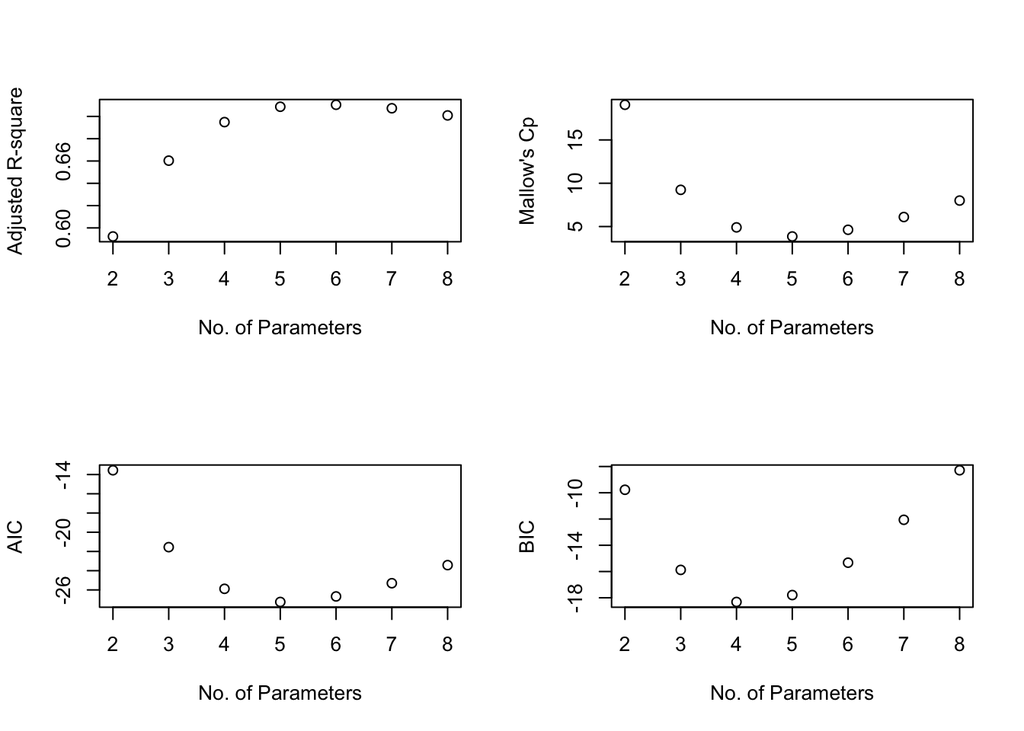

```r
b = regsubsets(Life.Exp ~., data=statedata[-2, ])
rs = summary(b)
n=49; msize = 2:8;
par(mfrow=c(2,2))
plot(msize, rs$adjr2, xlab="No. of Parameters", ylab = "Adjusted R-square");
plot(msize, rs$cp, xlab="No. of Parameters", ylab = "Mallow's Cp");
Aic = n*log(rs$rss/n) + 2*msize;
Bic = n*log(rs$rss/n) + msize*log(n);
plot(msize, Aic, xlab="No. of Parameters", ylab = "AIC");
plot(msize, Bic, xlab="No. of Parameters", ylab = "BIC")
```